# Historical data EDA z JustJoinIT (10.2021 – 09.2023)

# About the dataset

### Job offer data from JustJoinIT (10.2021 – 09.2023)

## Data collected (scraped) from one of the largest Polish IT job platforms.

This dataset contains daily snapshots of job offers collected from JustJoinIT – one of the largest Polish platforms with IT job postings. The dataset includes a variety of offers related to programming languages and IT fields (Java, C#, Python, JavaScript, data engineering, and others).

Job offers were collected from an API endpoint that provided all available offers. I created a simple AWS Lambda function that was triggered once a day and saved the collected data to S3. The data is raw – the original JSON provided by the API was saved to S3 without any processing.

First recorded day of data: October 23, 2021

Last recorded day of data: September 25, 2023

The dataset is incomplete (due to the lack of a retry mechanism in the script). Missing days:

- 2022-06-05
- 2022-09-12
- 2022-10-03
- 2022-10-10
- 2022-10-14
- 2022-10-17
- 2022-10-22
- 2022-10-23
- 2022-10-25
- 2022-10-29
- 2022-11-06
- 2022-11-12
- 2022-11-13
- 2022-12-11
- 2022-12-18
- 2022-12-26
- 2023-02-04
- 2023-02-07
- 2023-02-08
- 2023-02-26
- 2023-03-11
- 2023-03-12
- 2023-03-27
- 2023-04-03
- 2023-04-12
- 2023-04-14
- 2023-04-17
- 2023-04-19
- 2023-04-20
- 2023-04-21
- 2023-04-22
- 2023-04-24

#### Link to data:

https://www.kaggle.com/datasets/jszafranqb/justjoinit-job-offers-data-2021-10-2023-09

#### Autor of data:

https://www.kaggle.com/jszafranqb

# Analysis goals:

1. What was the average lifetime of a job offer?
2. Were there periodic increases and decreases in the number of job offers?
3. Which technologies were the most popular?
4. What was the situation of the Python language?
5. How many junior-level job offers were there?
6. What was the number of junior job offers compared to company size?
7. What was the overall outline of salaries?

## Step 1. Technical data overview

The data contains **229891** records and **19** columns.

|  | salary_from | salary_to |
| --- | --- | --- |
| count | 158750.000000 | 158750.000000 |
| mean | 14906.849058 | 20618.906318 |
| std | 7249.012939 | 8933.532744 |
| min | 350.000000 | 400.000000 |
| 25% | 10000.000000 | 15000.000000 |
| 50% | 15000.000000 | 20500.000000 |
| 75% | 20000.000000 | 26000.000000 |
| max | 290000.000000 | 390000.000000 |

### Basic information about the DataFrame

|  | Column | Duplicates | Non-null | Missing values | Percentage of missing values | Unique values | Data type |
| --- | --- | --- | --- | --- | --- | --- | --- |
| 0 | title | 0 | 229891 | 0 | 0.000000 | 31654 | object |
| 1 | city | 0 | 229891 | 0 | 0.000000 | 1575 | object |
| 2 | country_code | 0 | 229793 | 98 | 0.042647 | 86 | object |
| 3 | marker_icon | 0 | 229891 | 0 | 0.000000 | 24 | object |
| 4 | workplace_type | 0 | 229891 | 0 | 0.000000 | 3 | object |
| 5 | company_name | 0 | 229891 | 0 | 0.000000 | 7598 | object |
| 6 | company_size | 0 | 229891 | 0 | 0.000000 | 1093 | object |
| 7 | experience_level | 0 | 229891 | 0 | 0.000000 | 3 | object |
| 8 | remote_interview | 0 | 229891 | 0 | 0.000000 | 2 | bool |
| 9 | id | 0 | 229891 | 0 | 0.000000 | 229891 | object |
| 10 | skills | 0 | 229887 | 4 | 0.001740 | 42769 | object |
| 11 | remote | 0 | 229891 | 0 | 0.000000 | 2 | bool |
| 12 | type | 0 | 229891 | 0 | 0.000000 | 3 | object |
| 13 | salary_from | 0 | 158750 | 71141 | 44.813228 | 1113 | float64 |
| 14 | salary_to | 0 | 158750 | 71141 | 44.813228 | 1327 | float64 |
| 15 | salary_currency | 0 | 158750 | 71141 | 44.813228 | 5 | object |
| 16 | published_at_first | 0 | 229891 | 0 | 0.000000 | 104064 | object |
| 17 | published_at_last | 0 | 229891 | 0 | 0.000000 | 16413 | object |
| 18 | open_to_hire_ukrainians | 0 | 201776 | 28115 | 13.933768 | 2 | object |

### Summary of the technical data review:

- The data contains missing values to a small or easily fixable extent.
- The number of NaN values in the “salary” columns directly defines the number of job offers without salary ranges (44.8%).
- The data does not contain duplicates.
- The columns “remote_interview” and “remote” have boolean values, so their content can be changed to a more user-friendly form.
- The column “open_to_hire_ukrainians” can have missing values replaced with “Unknown”.
- The column “country_code” requires research.
- The column “open_to_hire_ukrainians” requires fixing; the recommended method is replacing NaN values with “unknown”.
- The column “company_size” should be cleaned and converted to a numeric type.
- The columns “published_at_first” and “published_at_last” should be converted to DateTime format.

# Step 2. Data cleaning

#### Creating a copy of the DataFrame

### 2.1 Column "city"

#### Capitalization of the "city" column

#### 2.1.2 Removing incorrect city names

```
array(['St. gallen', 'Athlone, ireland', 'London/remote', 'St. louis',
       'Bangkok, thailand', 'Poland, remote', 'Alicante (alacant)',
       'Kalmar, sweden', 'Sofia, bulgaria', 'Schwedt/oder',
       'Remote/anywhere poland'], dtype=object)
```

### 2.1.3 Fixing city names

### 2.2 Fixing column "country_code"

#### City names in records where missing values were detected in the "country_code" column

```
array(['Kraków', 'Europe', 'Warszawa', 'Katowice', 'Warsaw', 'Błonie',
       'Poznań', 'Wrocław', 'Gdańsk', 'Lwów', 'Zielona góra', 'Lublin',
       'Szczecin', 'Łódź', 'European union', 'Windhuk', 'Munich',
       'Bukareszt', 'Lizbon', 'Zurych', 'Barcelona', 'Madryt', 'Berlin',
       'Amsterdam', 'Dniepr', 'Gorzów wielkopolski', 'Poznan', 'London',
       'Prisztina', 'Limassol'], dtype=object)
```

|  | city | country_code |
| --- | --- | --- |

#### 2.2.1 Standardizing cities recorded as "European Union"

#### 2.2.2 Adding appropriate country codes

#### 2.3 Column "open_to_hire_ukrainians"

#### 2.3.1 Replacing NaN with the value "Unknown" and assigning readable aliases

### 2.4 Column "skills"

### 2.4.1 Removing records with NaN values

### 2.5. Column "company_size"

#### Converting values from type "string" (text) to "int" (integer)

### 2.6 Time columns

#### 2.6.1 Keeping data with second-level precision and converting to datetime format

#### 2.6.2 Checking how many records were loaded and removed within the same second

There are **4553** records that were loaded and removed in the same exact second, which accounts for 1.98% of all records. These are test or incorrect data and should be removed.

#### 2.6.3 Removing records loaded and removed in the same second

```
Number of remaining records: 225319
```

#### 2.6.4 Sorting data by the "published_at_first" column

#### 2.6.5 Removing records shorter than one day

```
count    225319.000000
mean         43.317638
std          55.282574
min           0.000012
25%          24.016134
50%          25.021644
75%          39.991204
max         716.999444
Name: lifetime_in_days, dtype: float64
```

There are 444 unlikely job offers shorter than 1 day. There are 1389 offers longer than 365 days.

#### 2.7.1 Replacing True and False with more user-friendly names in the "remote_interview" and "remote" columns

### Summary of Step 2: "Data Cleaning"

|  | Column | Duplicates | Non-null | Missing values | Percentage of missing values | Unique values | Data type |
| --- | --- | --- | --- | --- | --- | --- | --- |
| 0 | title | 0 | 224875 | 0 | 0.000000 | 31010 | object |
| 1 | city | 0 | 224875 | 0 | 0.000000 | 1537 | object |
| 2 | country_code | 0 | 224875 | 0 | 0.000000 | 84 | object |
| 3 | marker_icon | 0 | 224875 | 0 | 0.000000 | 24 | object |
| 4 | workplace_type | 0 | 224875 | 0 | 0.000000 | 3 | object |
| 5 | company_name | 0 | 224875 | 0 | 0.000000 | 7493 | object |
| 6 | company_size | 0 | 224772 | 103 | 0.045824 | 303 | float64 |
| 7 | experience_level | 0 | 224875 | 0 | 0.000000 | 3 | object |
| 8 | remote_interview | 0 | 224875 | 0 | 0.000000 | 2 | object |
| 9 | id | 0 | 224875 | 0 | 0.000000 | 224875 | object |
| 10 | skills | 0 | 224875 | 0 | 0.000000 | 41970 | object |
| 11 | remote | 0 | 224875 | 0 | 0.000000 | 2 | object |
| 12 | type | 0 | 224875 | 0 | 0.000000 | 3 | object |
| 13 | salary_from | 0 | 155354 | 69521 | 44.750055 | 1097 | float64 |
| 14 | salary_to | 0 | 155354 | 69521 | 44.750055 | 1309 | float64 |
| 15 | salary_currency | 0 | 155354 | 69521 | 44.750055 | 5 | object |
| 16 | published_at_first | 0 | 224875 | 0 | 0.000000 | 102124 | datetime64[ns] |
| 17 | published_at_last | 0 | 224875 | 0 | 0.000000 | 13704 | datetime64[ns] |
| 18 | open_to_hire_ukrainians | 0 | 224875 | 0 | 0.000000 | 3 | object |
| 19 | lifetime_in_days | 0 | 224875 | 0 | 0.000000 | 60446 | float64 |

The original DataFrame had 229891 records. After cleaning, 224875 records remain. It was reduced by 2.18%.

## Krok 3. Single variable analysis

## 3.1 Analysis of publication times.

### 3.1.1 Descriptive data and further modifications

|  | lifetime_in_days |
| --- | --- |
| Number of offers | 224875.00 |
| Average lifetime | 43.40 |
| Standard deviation | 55.30 |
| Shortest offer | 1.00 |
| 25% | 24.02 |
| 50% | 25.02 |
| 75% | 39.99 |
| Longest offer | 717.00 |

#### Key insights (lifetime_in_days)

- The typical lifetime of a job offer is around 25 days, corresponding to a standard 3–5 week IT recruitment cycle.
- The mean (43 days) is significantly skewed by offers remaining open for months, and even over 700 days, indicating outliers and data errors.
- 75% of offers disappear before day 40, so longer-active listings may require optimization.
- For reliable analyses, it is recommended to use offers with a lifetime <180 days to avoid distortions.

Offers longer than 180 days may indicate:

- errors in the source,
- renewed postings,
- permanent positions rather than actual recruitment.

The average lifetime of a job offer is 43.4 days

```
Over 180 days: 6542
Over 290 days: 2401
Over 365 days: 1389
```

#### 3.1.2 Removing offers longer than 180 days

|  | lifetime_in_days_less_than_180days |
| --- | --- |
| Number of offers | 218333.00 |
| Average lifetime | 35.79 |
| Standard deviation | 27.88 |
| Shortest offer | 1.00 |
| 25% | 24.01 |
| 50% | 25.02 |
| 75% | 35.00 |
| Longest offer | 179.99 |

#### The average lifetime of a job offer was **35.79** days

```
Number of offers 0–35 days: 163638 (74.95%)
Number of offers 36–60 days: 27740 (12.71%)
Number of offers 61–90 days: 13356 (6.12%)
Number of offers 91–120 days: 7115 (3.26%)
Number of offers over 120 days: 6484 (2.97%)
```

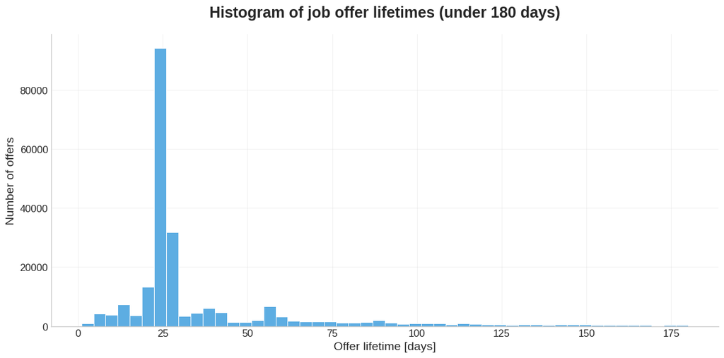

#### 3.1.3 Number of offers by month

|  | year | month | number_of_records |
| --- | --- | --- | --- |
| 0 | 2021 | 9 | 4 |
| 1 | 2021 | 10 | 6116 |
| 2 | 2021 | 11 | 4547 |
| 3 | 2021 | 12 | 3646 |
| 4 | 2022 | 1 | 4664 |
| 5 | 2022 | 2 | 5804 |
| 6 | 2022 | 3 | 7229 |
| 7 | 2022 | 4 | 7449 |
| 8 | 2022 | 5 | 8900 |
| 9 | 2022 | 6 | 10024 |
| 10 | 2022 | 7 | 10971 |
| 11 | 2022 | 8 | 13099 |
| 12 | 2022 | 9 | 13275 |
| 13 | 2022 | 10 | 12070 |
| 14 | 2022 | 11 | 10912 |
| 15 | 2022 | 12 | 7121 |
| 16 | 2023 | 1 | 11595 |
| 17 | 2023 | 2 | 11054 |
| 18 | 2023 | 3 | 12479 |
| 19 | 2023 | 4 | 10747 |
| 20 | 2023 | 5 | 11222 |
| 21 | 2023 | 6 | 9452 |
| 22 | 2023 | 7 | 9241 |
| 23 | 2023 | 8 | 10482 |
| 24 | 2023 | 9 | 6230 |

September 2021 has 4 records. They may distort the statistics, so they will be removed.

### Monthly aggregation on the offers

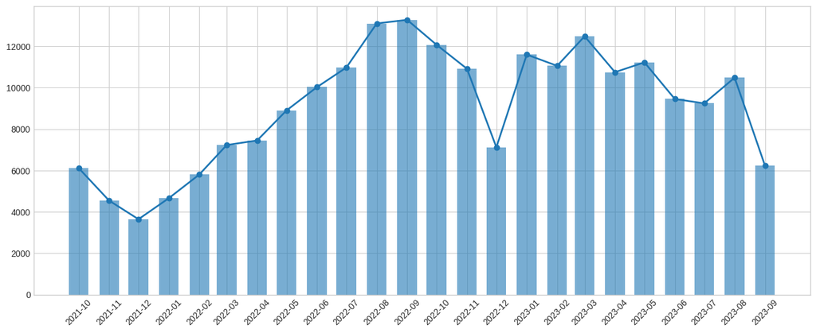

The end of 2021, from October to December, showed a decrease in posted job offers. A similar situation occurred from September 2022.  
Also in September 2023, a decline in posted offers began to appear, likely due to the last quarter of the year. Upward trends start from January and took various forms. In 2022, the upward trend continued until September.  
In 2023, the upward trend starting in January began from a higher level and was not as linear as in 2022. Between January and May it fluctuated. Then it declined from June, except for August.  
Such a low number of offers in December 2021 may have been caused by a drop in demand for specialists after the 2020 pandemic.

#### 3.1.4 Number of offers by month

```
Jan    16259
Feb    16858
Mar    19708
Apr    18196
May    20122
Jun    19476
Jul    20212
Aug    23581
Sep    19505
Oct    18186
Nov    15459
Dec    10767
dtype: int64
```

The highest number of job postings occurs from March to October. After that, we observe a decline in offers.

#### 3.1.5 Insights from the analysis of publication times

📌 Key insights (lifetime < 180 days)

## 3.2 Column 'remote'

Column 'remote' contains the following values:

Number of unique values: **2**

- **Remote**: 162727 (74.53%)

- **On-site**: 55602 (25.47%)

The dominant job type is remote work 162727 (74.53%), followed by on-site work 55602 (25.47%)

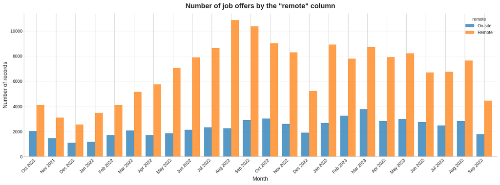

| remote | year | Month | On-site | % On-site | Remote | % Remote | Total |
| --- | --- | --- | --- | --- | --- | --- | --- |
| 0 | 2021 | Oct | 2016 | 32.960000 | 4100 | 67.040000 | 6116 |
| 1 | 2021 | Nov | 1450 | 31.890000 | 3097 | 68.110000 | 4547 |
| 2 | 2021 | Dec | 1093 | 29.980000 | 2553 | 70.020000 | 3646 |
| 3 | 2022 | Jan | 1189 | 25.490000 | 3475 | 74.510000 | 4664 |
| 4 | 2022 | Feb | 1713 | 29.510000 | 4091 | 70.490000 | 5804 |
| 5 | 2022 | Mar | 2076 | 28.720000 | 5153 | 71.280000 | 7229 |
| 6 | 2022 | Apr | 1708 | 22.930000 | 5741 | 77.070000 | 7449 |
| 7 | 2022 | May | 1849 | 20.780000 | 7051 | 79.220000 | 8900 |
| 8 | 2022 | Jun | 2135 | 21.300000 | 7889 | 78.700000 | 10024 |
| 9 | 2022 | Jul | 2330 | 21.240000 | 8641 | 78.760000 | 10971 |
| 10 | 2022 | Aug | 2241 | 17.110000 | 10858 | 82.890000 | 13099 |
| 11 | 2022 | Sep | 2907 | 21.900000 | 10368 | 78.100000 | 13275 |
| 12 | 2022 | Oct | 3038 | 25.170000 | 9032 | 74.830000 | 12070 |
| 13 | 2022 | Nov | 2609 | 23.910000 | 8303 | 76.090000 | 10912 |
| 14 | 2022 | Dec | 1907 | 26.780000 | 5214 | 73.220000 | 7121 |
| 15 | 2023 | Jan | 2675 | 23.070000 | 8920 | 76.930000 | 11595 |
| 16 | 2023 | Feb | 3246 | 29.360000 | 7808 | 70.640000 | 11054 |
| 17 | 2023 | Mar | 3767 | 30.190000 | 8712 | 69.810000 | 12479 |
| 18 | 2023 | Apr | 2826 | 26.300000 | 7921 | 73.700000 | 10747 |
| 19 | 2023 | May | 2996 | 26.700000 | 8226 | 73.300000 | 11222 |
| 20 | 2023 | Jun | 2742 | 29.010000 | 6710 | 70.990000 | 9452 |
| 21 | 2023 | Jul | 2488 | 26.920000 | 6753 | 73.080000 | 9241 |
| 22 | 2023 | Aug | 2826 | 26.960000 | 7656 | 73.040000 | 10482 |
| 23 | 2023 | Sep | 1775 | 28.490000 | 4455 | 71.510000 | 6230 |

## 3.3 Column "workplace_type"

The 'workplace_type' column contains categories:

Number of unique values: **3**

- **remote**: 162727 (74.53%)

- **partly_remote**: 49070 (22.48%)

- **office**: 6532 (2.99%)

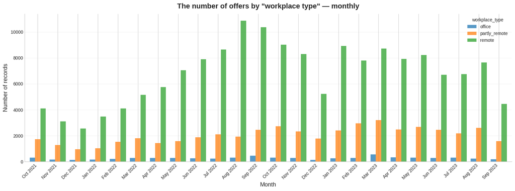

| workplace_type | year | Month | office | % office | partly_remote | % partly_remote | remote | % remote | Total |
| --- | --- | --- | --- | --- | --- | --- | --- | --- | --- |
| 0 | 2021 | Oct | 296 | 4.840000 | 1720 | 28.120000 | 4100 | 67.040000 | 6116 |
| 1 | 2021 | Nov | 161 | 3.540000 | 1289 | 28.350000 | 3097 | 68.110000 | 4547 |
| 2 | 2021 | Dec | 142 | 3.890000 | 951 | 26.080000 | 2553 | 70.020000 | 3646 |
| 3 | 2022 | Jan | 155 | 3.320000 | 1034 | 22.170000 | 3475 | 74.510000 | 4664 |
| 4 | 2022 | Feb | 197 | 3.390000 | 1516 | 26.120000 | 4091 | 70.490000 | 5804 |
| 5 | 2022 | Mar | 283 | 3.910000 | 1793 | 24.800000 | 5153 | 71.280000 | 7229 |
| 6 | 2022 | Apr | 278 | 3.730000 | 1430 | 19.200000 | 5741 | 77.070000 | 7449 |
| 7 | 2022 | May | 278 | 3.120000 | 1571 | 17.650000 | 7051 | 79.220000 | 8900 |
| 8 | 2022 | Jun | 259 | 2.580000 | 1876 | 18.720000 | 7889 | 78.700000 | 10024 |
| 9 | 2022 | Jul | 221 | 2.010000 | 2109 | 19.220000 | 8641 | 78.760000 | 10971 |
| 10 | 2022 | Aug | 316 | 2.410000 | 1925 | 14.700000 | 10858 | 82.890000 | 13099 |
| 11 | 2022 | Sep | 443 | 3.340000 | 2464 | 18.560000 | 10368 | 78.100000 | 13275 |
| 12 | 2022 | Oct | 314 | 2.600000 | 2724 | 22.570000 | 9032 | 74.830000 | 12070 |
| 13 | 2022 | Nov | 290 | 2.660000 | 2319 | 21.250000 | 8303 | 76.090000 | 10912 |
| 14 | 2022 | Dec | 131 | 1.840000 | 1776 | 24.940000 | 5214 | 73.220000 | 7121 |
| 15 | 2023 | Jan | 262 | 2.260000 | 2413 | 20.810000 | 8920 | 76.930000 | 11595 |
| 16 | 2023 | Feb | 282 | 2.550000 | 2964 | 26.810000 | 7808 | 70.640000 | 11054 |
| 17 | 2023 | Mar | 563 | 4.510000 | 3204 | 25.680000 | 8712 | 69.810000 | 12479 |
| 18 | 2023 | Apr | 341 | 3.170000 | 2485 | 23.120000 | 7921 | 73.700000 | 10747 |
| 19 | 2023 | May | 308 | 2.740000 | 2688 | 23.950000 | 8226 | 73.300000 | 11222 |
| 20 | 2023 | Jun | 284 | 3.000000 | 2458 | 26.010000 | 6710 | 70.990000 | 9452 |
| 21 | 2023 | Jul | 315 | 3.410000 | 2173 | 23.510000 | 6753 | 73.080000 | 9241 |
| 22 | 2023 | Aug | 224 | 2.140000 | 2602 | 24.820000 | 7656 | 73.040000 | 10482 |
| 23 | 2023 | Sep | 189 | 3.030000 | 1586 | 25.460000 | 4455 | 71.510000 | 6230 |

## 3.4 Column "open_to_hire_ukrainians"

The 'open_to_hire_ukrainians' column contains categories:

Number of unique values: **3**

- **Does not matter**: 127505 (58.4%)

- **Open to Ukrainians**: 66337 (30.38%)

- **Unknown**: 24487 (11.22%)

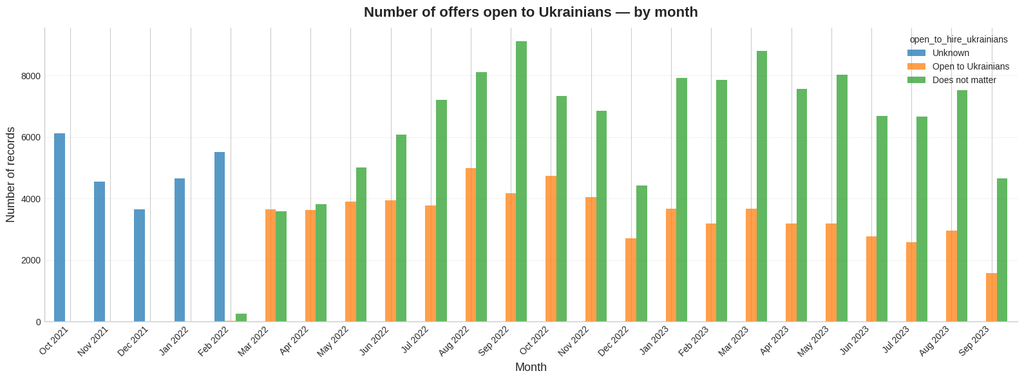

| open_to_hire_ukrainians | year | Month | Unknown | % Unknown | Open to Ukrainians | % Open to Ukrainians | Does not matter | % Does not matter | Total |
| --- | --- | --- | --- | --- | --- | --- | --- | --- | --- |
| 0 | 2021 | Oct | 6116 | 100.000000 | 0 | 0.000000 | 0 | 0.000000 | 6116 |
| 1 | 2021 | Nov | 4547 | 100.000000 | 0 | 0.000000 | 0 | 0.000000 | 4547 |
| 2 | 2021 | Dec | 3646 | 100.000000 | 0 | 0.000000 | 0 | 0.000000 | 3646 |
| 3 | 2022 | Jan | 4664 | 100.000000 | 0 | 0.000000 | 0 | 0.000000 | 4664 |
| 4 | 2022 | Feb | 5514 | 95.000000 | 27 | 0.470000 | 263 | 4.530000 | 5804 |
| 5 | 2022 | Mar | 0 | 0.000000 | 3639 | 50.340000 | 3590 | 49.660000 | 7229 |
| 6 | 2022 | Apr | 0 | 0.000000 | 3630 | 48.730000 | 3819 | 51.270000 | 7449 |
| 7 | 2022 | May | 0 | 0.000000 | 3897 | 43.790000 | 5003 | 56.210000 | 8900 |
| 8 | 2022 | Jun | 0 | 0.000000 | 3942 | 39.330000 | 6082 | 60.670000 | 10024 |
| 9 | 2022 | Jul | 0 | 0.000000 | 3767 | 34.340000 | 7204 | 65.660000 | 10971 |
| 10 | 2022 | Aug | 0 | 0.000000 | 4991 | 38.100000 | 8108 | 61.900000 | 13099 |
| 11 | 2022 | Sep | 0 | 0.000000 | 4168 | 31.400000 | 9107 | 68.600000 | 13275 |
| 12 | 2022 | Oct | 0 | 0.000000 | 4744 | 39.300000 | 7326 | 60.700000 | 12070 |
| 13 | 2022 | Nov | 0 | 0.000000 | 4053 | 37.140000 | 6859 | 62.860000 | 10912 |
| 14 | 2022 | Dec | 0 | 0.000000 | 2705 | 37.990000 | 4416 | 62.010000 | 7121 |
| 15 | 2023 | Jan | 0 | 0.000000 | 3663 | 31.590000 | 7932 | 68.410000 | 11595 |
| 16 | 2023 | Feb | 0 | 0.000000 | 3197 | 28.920000 | 7857 | 71.080000 | 11054 |
| 17 | 2023 | Mar | 0 | 0.000000 | 3669 | 29.400000 | 8810 | 70.600000 | 12479 |
| 18 | 2023 | Apr | 0 | 0.000000 | 3188 | 29.660000 | 7559 | 70.340000 | 10747 |
| 19 | 2023 | May | 0 | 0.000000 | 3195 | 28.470000 | 8027 | 71.530000 | 11222 |
| 20 | 2023 | Jun | 0 | 0.000000 | 2759 | 29.190000 | 6693 | 70.810000 | 9452 |
| 21 | 2023 | Jul | 0 | 0.000000 | 2585 | 27.970000 | 6656 | 72.030000 | 9241 |
| 22 | 2023 | Aug | 0 | 0.000000 | 2949 | 28.130000 | 7533 | 71.870000 | 10482 |
| 23 | 2023 | Sep | 0 | 0.000000 | 1569 | 25.180000 | 4661 | 74.820000 | 6230 |

## 3.5 Column "remote_interview"

The categories column 'remote_interview' contains categories:

Number of unique values: **2**

- **Remote interview**: 167153 (76.56%)

- **On-site interview**: 51176 (23.44%)

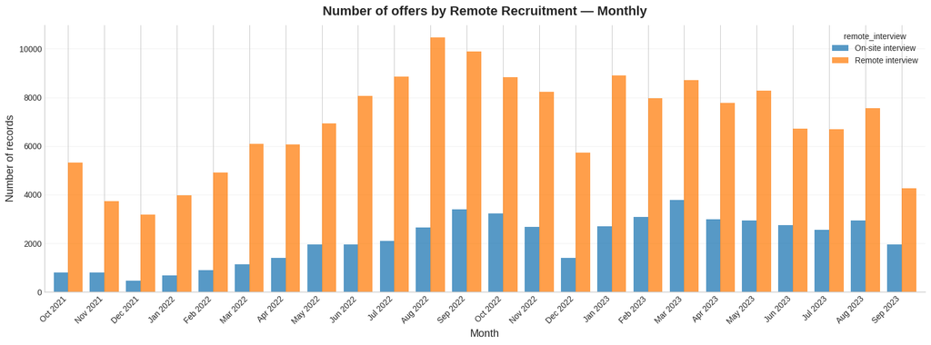

| remote_interview | year | Month | On-site interview | % On-site interview | Remote interview | % Remote interview | Total |
| --- | --- | --- | --- | --- | --- | --- | --- |
| 0 | 2021 | Oct | 787 | 12.870000 | 5329 | 87.130000 | 6116 |
| 1 | 2021 | Nov | 805 | 17.700000 | 3742 | 82.300000 | 4547 |
| 2 | 2021 | Dec | 465 | 12.750000 | 3181 | 87.250000 | 3646 |
| 3 | 2022 | Jan | 683 | 14.640000 | 3981 | 85.360000 | 4664 |
| 4 | 2022 | Feb | 889 | 15.320000 | 4915 | 84.680000 | 5804 |
| 5 | 2022 | Mar | 1141 | 15.780000 | 6088 | 84.220000 | 7229 |
| 6 | 2022 | Apr | 1391 | 18.670000 | 6058 | 81.330000 | 7449 |
| 7 | 2022 | May | 1958 | 22.000000 | 6942 | 78.000000 | 8900 |
| 8 | 2022 | Jun | 1954 | 19.490000 | 8070 | 80.510000 | 10024 |
| 9 | 2022 | Jul | 2103 | 19.170000 | 8868 | 80.830000 | 10971 |
| 10 | 2022 | Aug | 2641 | 20.160000 | 10458 | 79.840000 | 13099 |
| 11 | 2022 | Sep | 3393 | 25.560000 | 9882 | 74.440000 | 13275 |
| 12 | 2022 | Oct | 3235 | 26.800000 | 8835 | 73.200000 | 12070 |
| 13 | 2022 | Nov | 2682 | 24.580000 | 8230 | 75.420000 | 10912 |
| 14 | 2022 | Dec | 1395 | 19.590000 | 5726 | 80.410000 | 7121 |
| 15 | 2023 | Jan | 2689 | 23.190000 | 8906 | 76.810000 | 11595 |
| 16 | 2023 | Feb | 3078 | 27.850000 | 7976 | 72.150000 | 11054 |
| 17 | 2023 | Mar | 3779 | 30.280000 | 8700 | 69.720000 | 12479 |
| 18 | 2023 | Apr | 2981 | 27.740000 | 7766 | 72.260000 | 10747 |
| 19 | 2023 | May | 2947 | 26.260000 | 8275 | 73.740000 | 11222 |
| 20 | 2023 | Jun | 2745 | 29.040000 | 6707 | 70.960000 | 9452 |
| 21 | 2023 | Jul | 2551 | 27.610000 | 6690 | 72.390000 | 9241 |
| 22 | 2023 | Aug | 2928 | 27.930000 | 7554 | 72.070000 | 10482 |
| 23 | 2023 | Sep | 1956 | 31.400000 | 4274 | 68.600000 | 6230 |

#### Conclusions from the analysis of the "remote_interview" column

- General overview (number and proportion of records) is similar to the "remote" column.

The overall trend may resemble the situation observed in the ratio of Remote vs. On-site Work, but it is not identical.

## 3.6 Column "type" (contract type)

The 'type' column contains categories:

Number of unique values: **3**

- **b2b**: 134323 (61.52%)

- **permanent**: 81086 (37.14%)

- **mandate_contract**: 2920 (1.34%)

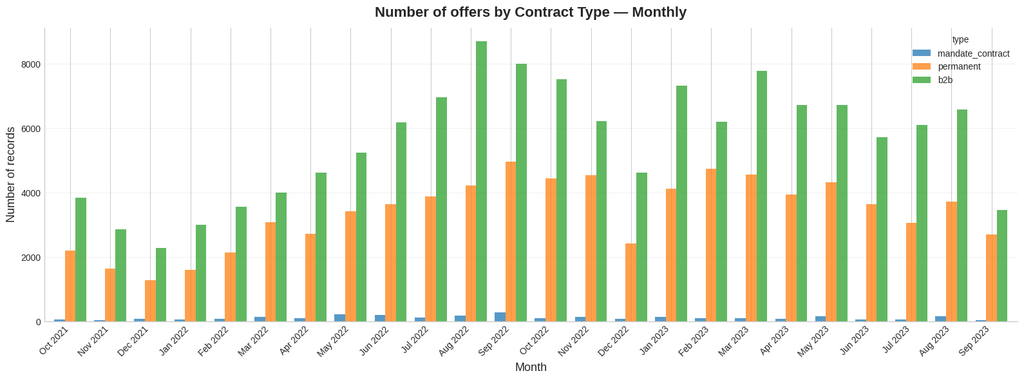

| type | year | Month | mandate_contract | % mandate_contract | permanent | % permanent | b2b | % b2b | Total |
| --- | --- | --- | --- | --- | --- | --- | --- | --- | --- |
| 0 | 2021 | Oct | 67 | 1.100000 | 2195 | 35.890000 | 3854 | 63.020000 | 6116 |
| 1 | 2021 | Nov | 51 | 1.120000 | 1635 | 35.960000 | 2861 | 62.920000 | 4547 |
| 2 | 2021 | Dec | 87 | 2.390000 | 1275 | 34.970000 | 2284 | 62.640000 | 3646 |
| 3 | 2022 | Jan | 55 | 1.180000 | 1614 | 34.610000 | 2995 | 64.220000 | 4664 |
| 4 | 2022 | Feb | 91 | 1.570000 | 2147 | 36.990000 | 3566 | 61.440000 | 5804 |
| 5 | 2022 | Mar | 144 | 1.990000 | 3085 | 42.680000 | 4000 | 55.330000 | 7229 |
| 6 | 2022 | Apr | 104 | 1.400000 | 2724 | 36.570000 | 4621 | 62.040000 | 7449 |
| 7 | 2022 | May | 219 | 2.460000 | 3431 | 38.550000 | 5250 | 58.990000 | 8900 |
| 8 | 2022 | Jun | 206 | 2.060000 | 3641 | 36.320000 | 6177 | 61.620000 | 10024 |
| 9 | 2022 | Jul | 121 | 1.100000 | 3893 | 35.480000 | 6957 | 63.410000 | 10971 |
| 10 | 2022 | Aug | 177 | 1.350000 | 4224 | 32.250000 | 8698 | 66.400000 | 13099 |
| 11 | 2022 | Sep | 292 | 2.200000 | 4972 | 37.450000 | 8011 | 60.350000 | 13275 |
| 12 | 2022 | Oct | 104 | 0.860000 | 4438 | 36.770000 | 7528 | 62.370000 | 12070 |
| 13 | 2022 | Nov | 141 | 1.290000 | 4539 | 41.600000 | 6232 | 57.110000 | 10912 |
| 14 | 2022 | Dec | 87 | 1.220000 | 2418 | 33.960000 | 4616 | 64.820000 | 7121 |
| 15 | 2023 | Jan | 148 | 1.280000 | 4115 | 35.490000 | 7332 | 63.230000 | 11595 |
| 16 | 2023 | Feb | 105 | 0.950000 | 4744 | 42.920000 | 6205 | 56.130000 | 11054 |
| 17 | 2023 | Mar | 110 | 0.880000 | 4574 | 36.650000 | 7795 | 62.460000 | 12479 |
| 18 | 2023 | Apr | 90 | 0.840000 | 3940 | 36.660000 | 6717 | 62.500000 | 10747 |
| 19 | 2023 | May | 169 | 1.510000 | 4330 | 38.580000 | 6723 | 59.910000 | 11222 |
| 20 | 2023 | Jun | 73 | 0.770000 | 3646 | 38.570000 | 5733 | 60.650000 | 9452 |
| 21 | 2023 | Jul | 71 | 0.770000 | 3071 | 33.230000 | 6099 | 66.000000 | 9241 |
| 22 | 2023 | Aug | 165 | 1.570000 | 3722 | 35.510000 | 6595 | 62.920000 | 10482 |
| 23 | 2023 | Sep | 43 | 0.690000 | 2713 | 43.550000 | 3474 | 55.760000 | 6230 |

#### Conclusions from the analysis of the "type" column (contract type)

B2B remains the dominant contract type (55–66%), although its share slightly decreases in 2023. Permanent contracts are gaining strength, especially at the beginning of 2023 (up to ~43%), indicating more stable employment. Mandate_contract is a marginal category (<3%). Seasonally, there are drops in offers in December and slight fluctuations during the summer, while the rest of the year remains stable.

## 3.7 Column "Marker icon"

The 'marker_icon' column contains categories:

Number of unique values: **24**

- **javascript**: 28957 (13.26%)

- **java**: 22825 (10.45%)

- **testing**: 15221 (6.97%)

- **net**: 15170 (6.95%)

- **devops**: 14850 (6.8%)

- **data**: 13725 (6.29%)

- **pm**: 11104 (5.09%)

- **python**: 10804 (4.95%)

- **php**: 9808 (4.49%)

- **admin**: 9115 (4.17%)

- **mobile**: 8473 (3.88%)

- **analytics**: 8245 (3.78%)

- **support**: 7801 (3.57%)

- **other**: 7508 (3.44%)

- **architecture**: 6966 (3.19%)

- **c**: 6538 (2.99%)

- **erp**: 4917 (2.25%)

- **security**: 4429 (2.03%)

- **ux**: 4157 (1.9%)

- **ruby**: 2291 (1.05%)

- **go**: 1711 (0.78%)

- **game**: 1572 (0.72%)

- **html**: 1321 (0.61%)

- **scala**: 821 (0.38%)

#### We can assume these are the most sought-after technologies or skills

Analysis of selected technologies in the `marker_icon` column

Number of records in the dataset: **218329**

- **javascript**: 28957 (13.26%)

- **data**: 13725 (6.29%)

- **python**: 10804 (4.95%)

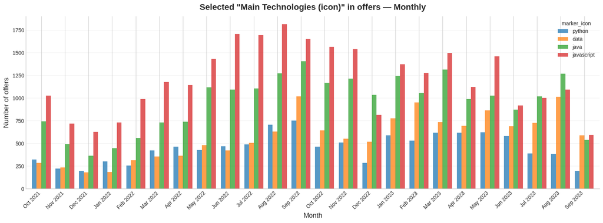

| marker_icon | year | Month | python | % python | data | % data | java | % java | javascript | % javascript | Total |
| --- | --- | --- | --- | --- | --- | --- | --- | --- | --- | --- | --- |
| 0 | 2021 | Oct | 322 | 13.540000 | 286 | 12.020000 | 745 | 31.320000 | 1026 | 43.130000 | 2379 |
| 1 | 2021 | Nov | 222 | 13.330000 | 234 | 14.050000 | 493 | 29.590000 | 717 | 43.040000 | 1666 |
| 2 | 2021 | Dec | 197 | 14.430000 | 180 | 13.190000 | 363 | 26.590000 | 625 | 45.790000 | 1365 |
| 3 | 2022 | Jan | 301 | 18.080000 | 185 | 11.110000 | 449 | 26.970000 | 730 | 43.840000 | 1665 |
| 4 | 2022 | Feb | 257 | 12.110000 | 313 | 14.750000 | 561 | 26.440000 | 991 | 46.700000 | 2122 |
| 5 | 2022 | Mar | 420 | 15.670000 | 354 | 13.210000 | 729 | 27.200000 | 1177 | 43.920000 | 2680 |
| 6 | 2022 | Apr | 462 | 17.070000 | 365 | 13.480000 | 737 | 27.230000 | 1143 | 42.220000 | 2707 |
| 7 | 2022 | May | 428 | 12.360000 | 482 | 13.920000 | 1119 | 32.320000 | 1433 | 41.390000 | 3462 |
| 8 | 2022 | Jun | 467 | 12.660000 | 422 | 11.440000 | 1094 | 29.660000 | 1706 | 46.250000 | 3689 |
| 9 | 2022 | Jul | 489 | 12.890000 | 506 | 13.330000 | 1107 | 29.170000 | 1693 | 44.610000 | 3795 |
| 10 | 2022 | Aug | 707 | 15.990000 | 629 | 14.220000 | 1273 | 28.790000 | 1813 | 41.000000 | 4422 |
| 11 | 2022 | Sep | 751 | 15.570000 | 1017 | 21.080000 | 1406 | 29.150000 | 1650 | 34.200000 | 4824 |
| 12 | 2022 | Oct | 463 | 12.060000 | 642 | 16.720000 | 1168 | 30.420000 | 1566 | 40.790000 | 3839 |
| 13 | 2022 | Nov | 508 | 13.320000 | 552 | 14.480000 | 1215 | 31.860000 | 1538 | 40.340000 | 3813 |
| 14 | 2022 | Dec | 285 | 10.740000 | 516 | 19.440000 | 1037 | 39.070000 | 816 | 30.750000 | 2654 |
| 15 | 2023 | Jan | 589 | 14.800000 | 777 | 19.520000 | 1243 | 31.220000 | 1372 | 34.460000 | 3981 |
| 16 | 2023 | Feb | 530 | 13.900000 | 952 | 24.970000 | 1054 | 27.650000 | 1276 | 33.470000 | 3812 |
| 17 | 2023 | Mar | 619 | 14.880000 | 733 | 17.620000 | 1313 | 31.550000 | 1496 | 35.950000 | 4161 |
| 18 | 2023 | Apr | 616 | 17.990000 | 695 | 20.300000 | 991 | 28.940000 | 1122 | 32.770000 | 3424 |
| 19 | 2023 | May | 623 | 15.670000 | 866 | 21.780000 | 1028 | 25.850000 | 1460 | 36.710000 | 3977 |
| 20 | 2023 | Jun | 581 | 19.000000 | 687 | 22.470000 | 872 | 28.520000 | 918 | 30.020000 | 3058 |
| 21 | 2023 | Jul | 387 | 12.340000 | 727 | 23.190000 | 1020 | 32.540000 | 1001 | 31.930000 | 3135 |
| 22 | 2023 | Aug | 384 | 10.210000 | 1015 | 26.980000 | 1268 | 33.710000 | 1095 | 29.110000 | 3762 |
| 23 | 2023 | Sep | 196 | 10.210000 | 590 | 30.750000 | 540 | 28.140000 | 593 | 30.900000 | 1919 |

### Conclusions for the 'Python' technology:

#### Year 2021

- The number of offers ranged from ~197 to 322 per month.
- The percentage share of Python offers ranged between 12–14%.
- There is a decrease in the number of offers towards the end of the year – a declining trend in Q4.

#### Overall observation

- Compared to 2021 and 2022, the average number of Python offers in 2023 was higher.
- The increase was not uniform – seasonal spikes and monthly fluctuations were observed.
- The annual trend shows that Python was becoming increasingly popular, but no stable, consistent monthly growth was observed.

#### Conclusions for 'Python'

- The biggest increase in interest in Python occurred in 2022, where the number of offers grew almost continuously from January to September — this was the most dynamic period for this technology.
- The year 2023 started very strong, with a high share of Python offers (14–19%), but after June there was a noticeable decline in both the number of offers and the percentage shares.
- The end of the years (October–December 2021, 2022, and September 2023) brings the fewest Python offers, which aligns with the overall decrease in total job postings in Q4.

### Conclusions for 'Data Work' (data):

- In 2023, the number of offers related to data work was generally higher than in 2022, e.g., in February it increased to 952 offers (24.97%), and in September it reached the highest share of 30.75%.
- The trend showed seasonal fluctuations, with a higher number of offers in Q2 and Q3, while drops occurred in some months between July and September.
- The percentage share of "Data" offers in the total number of offers gradually increased throughout the year, indicating growing interest in data-related work in job postings.

### Conclusions for the 'JavaScript' technology

- The number of offers in 2023 was lower than in most months of 2022, indicating a general decline in interest in JavaScript job postings during the analyzed period.
- The percentage share of JavaScript offers also gradually decreased – in January 2023 it was 34.46%, and by September it dropped to 30.90%, whereas in peak months of 2022 (e.g., June – 46.25%) it was significantly higher.
- Seasonal fluctuations are visible – the lowest percentage values were recorded in June and August 2023 (30–31%), with short rebounds in March and May 2023 (35–36%).
- Overall, it can be concluded that in 2023 the JavaScript job market lost share compared to the previous year, even though short-term increases occurred in some months.

## 3.8 Column "skills"

## 3.8.1 General overvie of column "skills"

There are 10592 different required skills and technologies in offers with specified salaries

```
There are 10592 different required skills and technologies
```

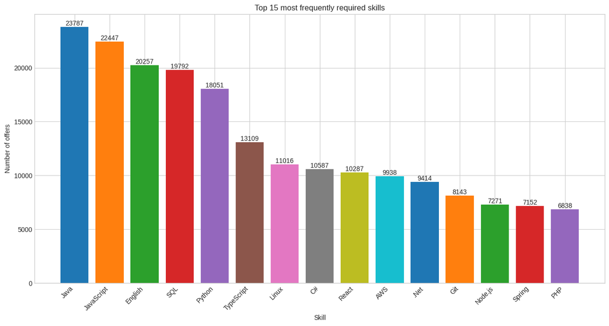

#### The direct distribution of technologies from the 'skills' column differs from 'marker_icon', which is more general.

The "Java" language takes the first place, followed by "JavaScript" in second. The "Python" language ranks fourth (after "English" if we assume English is not a technology). This gives a completely different picture of technology requirements.

## 3.8.2 Examination of the 4 most popular technologies: Java, JavaScript, SQL, and Python

```
There are 715 offers labeled as JavaScript that also require Java
There are 357 offers labeled as JavaScript that also require Python
There are 1098 offers labeled as Java that also require JavaScript
There are 478 offers labeled as Java that also require Python
There are 3882 offers labeled as Data that also require Python
There are 6575 offers labeled as Data that also require SQL
```

Distribution of selected technologies in the 'skills' column

Number of records: **218329**

- **Java**: 50002 (22.9%)

- **JavaScript**: 23246 (10.65%)

- **SQL**: 32218 (14.76%)

- **Python**: 19611 (8.98%)

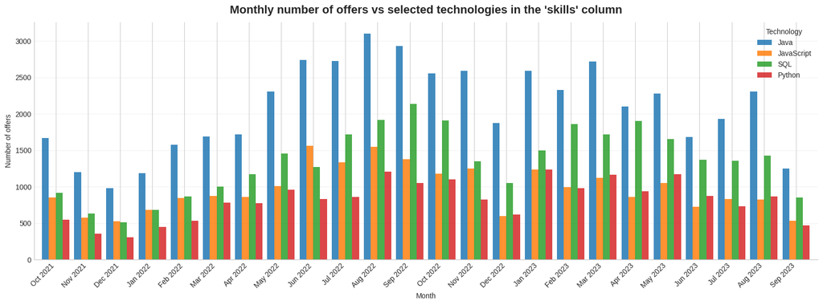

|  | year | Month | Java | % Java | JavaScript | % JavaScript | SQL | % SQL | Python | % Python | Total |
| --- | --- | --- | --- | --- | --- | --- | --- | --- | --- | --- | --- |
| 0 | 2021 | Oct | 1665 | 41.890000 | 851 | 21.410000 | 913 | 22.970000 | 546 | 13.740000 | 3975 |
| 1 | 2021 | Nov | 1200 | 43.350000 | 575 | 20.770000 | 634 | 22.900000 | 359 | 12.970000 | 2768 |
| 2 | 2021 | Dec | 977 | 42.150000 | 529 | 22.820000 | 509 | 21.960000 | 303 | 13.070000 | 2318 |
| 3 | 2022 | Jan | 1186 | 39.600000 | 682 | 22.770000 | 680 | 22.700000 | 447 | 14.920000 | 2995 |
| 4 | 2022 | Feb | 1573 | 41.230000 | 844 | 22.120000 | 864 | 22.650000 | 534 | 14.000000 | 3815 |
| 5 | 2022 | Mar | 1691 | 38.920000 | 875 | 20.140000 | 1000 | 23.010000 | 779 | 17.930000 | 4345 |
| 6 | 2022 | Apr | 1715 | 37.980000 | 857 | 18.980000 | 1172 | 25.950000 | 772 | 17.090000 | 4516 |
| 7 | 2022 | May | 2305 | 40.280000 | 1008 | 17.620000 | 1452 | 25.380000 | 957 | 16.720000 | 5722 |
| 8 | 2022 | Jun | 2735 | 42.770000 | 1559 | 24.380000 | 1272 | 19.890000 | 828 | 12.950000 | 6394 |
| 9 | 2022 | Jul | 2723 | 41.060000 | 1334 | 20.120000 | 1715 | 25.860000 | 859 | 12.950000 | 6631 |
| 10 | 2022 | Aug | 3103 | 39.920000 | 1550 | 19.940000 | 1915 | 24.630000 | 1206 | 15.510000 | 7774 |
| 11 | 2022 | Sep | 2932 | 39.100000 | 1378 | 18.380000 | 2138 | 28.510000 | 1050 | 14.000000 | 7498 |
| 12 | 2022 | Oct | 2551 | 37.830000 | 1179 | 17.480000 | 1910 | 28.330000 | 1103 | 16.360000 | 6743 |
| 13 | 2022 | Nov | 2590 | 43.030000 | 1252 | 20.800000 | 1352 | 22.460000 | 825 | 13.710000 | 6019 |
| 14 | 2022 | Dec | 1874 | 45.210000 | 599 | 14.450000 | 1054 | 25.430000 | 618 | 14.910000 | 4145 |
| 15 | 2023 | Jan | 2591 | 39.480000 | 1235 | 18.820000 | 1499 | 22.840000 | 1238 | 18.860000 | 6563 |
| 16 | 2023 | Feb | 2329 | 37.790000 | 994 | 16.130000 | 1861 | 30.200000 | 979 | 15.890000 | 6163 |
| 17 | 2023 | Mar | 2720 | 40.440000 | 1123 | 16.700000 | 1720 | 25.570000 | 1163 | 17.290000 | 6726 |
| 18 | 2023 | Apr | 2097 | 36.200000 | 861 | 14.860000 | 1900 | 32.800000 | 935 | 16.140000 | 5793 |
| 19 | 2023 | May | 2274 | 37.000000 | 1048 | 17.050000 | 1656 | 26.940000 | 1168 | 19.000000 | 6146 |
| 20 | 2023 | Jun | 1685 | 36.190000 | 725 | 15.570000 | 1372 | 29.470000 | 874 | 18.770000 | 4656 |
| 21 | 2023 | Jul | 1932 | 39.790000 | 831 | 17.120000 | 1357 | 27.950000 | 735 | 15.140000 | 4855 |
| 22 | 2023 | Aug | 2306 | 42.570000 | 821 | 15.160000 | 1424 | 26.290000 | 866 | 15.990000 | 5417 |
| 23 | 2023 | Sep | 1248 | 40.260000 | 536 | 17.290000 | 849 | 27.390000 | 467 | 15.060000 | 3100 |

#### Conclusions from the analysis of the 4 most frequently required technologies:

#### Java

- Java remained the most frequently required language in job offers throughout the period.
- Dips occurred in February and April 2023 (share ~36–37%), possibly due to seasonal recruitment slowdowns in some projects or budget shifts.
- Peaks were observed at the end of 2022, e.g., December 2022 (~45% share), suggesting increased demand at year-end or completion of projects requiring Java.
- Java remained a key technology, with short declines likely related to project cycles rather than reduced demand.

#### JavaScript

- JavaScript gradually lost share in job offers compared to Java and SQL.
- Dips in 2023 (e.g., April 2023 ~15%, September 2023 ~17%) indicate a decline in its prominence in offers in the first half of the year.
- Peaks occurred in mid-2022 (~24%), possibly due to larger frontend or web projects during that period.
- Conclusion: JavaScript remained important, but its share decreased over time, which may reflect a shift of projects toward backend development and data analytics.

#### SQL

- SQL gradually increased its share in job offers, from ~22% in 2021 to ~27–32% in selected months of 2023.
- Peaks appeared in March 2022, September 2022, and April 2023 (~25–32%), indicating growing demand for data analytics and databases in projects.
- Dips in June 2022 (~20%) were likely due to seasonality.
- Conclusion: SQL became an increasingly important skill, especially in analytical and data processing projects, confirming the growing significance of data in companies.

#### Python

- Python remained relatively stable, with a share of ~12–19%.
- Peaks in March and May 2022 (~17–18%) and May and June 2023 (~18–19%) indicate periodic increased demand for data analysts and data engineers.
- Dips in December 2021 (~13%) and September 2023 (~15%) show minimal fluctuations, without dramatic changes.
- Python was consistently present in job offers, largely in data-related projects, but its share did not dominate the market.

### Conclusions from the analysis of technologies in the *marker_icon* and *skills* columns

This shows that Python appeared more often in skill sets than as the main “marker” of the offer, suggesting it was an important supplementary skill but less frequently the dominant technology. In contrast, Java and JavaScript were relatively stable at the top in both analyses, while SQL/Data showed similar trends, although its percentage share in skills was slightly higher than in marker_icon.

In summary: overall trends were consistent, but skills provides a fuller picture of the technologies in job offers, while marker_icon more clearly indicates the dominant technology.

## 3.9 Columna 'experience_level'

The 'experience_level' column contains categories:

Number of unique values: **3**

- **mid**: 115853 (53.06%)

- **senior**: 86158 (39.46%)

- **junior**: 16318 (7.47%)

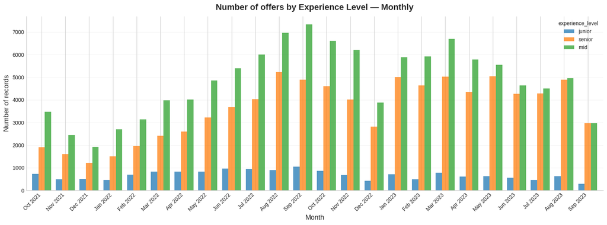

The share of juniors in the market remained consistently low, and its fluctuations did not significantly deviate from the overall trend in the number of offers.  
We observe a slight upward trend in 2022, followed by a decline in 2023.

As offers dominated by mids and seniors increased, the percentage of juniors decreased, since the market demand was mainly driven by mid- and senior-level positions.

| experience_level | year | Month | junior | % junior | senior | % senior | mid | % mid | Total |
| --- | --- | --- | --- | --- | --- | --- | --- | --- | --- |
| 0 | 2021 | Oct | 735 | 12.020000 | 1901 | 31.080000 | 3480 | 56.900000 | 6116 |
| 1 | 2021 | Nov | 491 | 10.800000 | 1604 | 35.280000 | 2452 | 53.930000 | 4547 |
| 2 | 2021 | Dec | 507 | 13.910000 | 1216 | 33.350000 | 1923 | 52.740000 | 3646 |
| 3 | 2022 | Jan | 456 | 9.780000 | 1500 | 32.160000 | 2708 | 58.060000 | 4664 |
| 4 | 2022 | Feb | 701 | 12.080000 | 1964 | 33.840000 | 3139 | 54.080000 | 5804 |
| 5 | 2022 | Mar | 836 | 11.560000 | 2406 | 33.280000 | 3987 | 55.150000 | 7229 |
| 6 | 2022 | Apr | 837 | 11.240000 | 2600 | 34.900000 | 4012 | 53.860000 | 7449 |
| 7 | 2022 | May | 822 | 9.240000 | 3224 | 36.220000 | 4854 | 54.540000 | 8900 |
| 8 | 2022 | Jun | 958 | 9.560000 | 3674 | 36.650000 | 5392 | 53.790000 | 10024 |
| 9 | 2022 | Jul | 944 | 8.600000 | 4026 | 36.700000 | 6001 | 54.700000 | 10971 |
| 10 | 2022 | Aug | 901 | 6.880000 | 5226 | 39.900000 | 6972 | 53.230000 | 13099 |
| 11 | 2022 | Sep | 1048 | 7.890000 | 4899 | 36.900000 | 7328 | 55.200000 | 13275 |
| 12 | 2022 | Oct | 858 | 7.110000 | 4597 | 38.090000 | 6615 | 54.810000 | 12070 |
| 13 | 2022 | Nov | 676 | 6.200000 | 4022 | 36.860000 | 6214 | 56.950000 | 10912 |
| 14 | 2022 | Dec | 426 | 5.980000 | 2810 | 39.460000 | 3885 | 54.560000 | 7121 |
| 15 | 2023 | Jan | 705 | 6.080000 | 5001 | 43.130000 | 5889 | 50.790000 | 11595 |
| 16 | 2023 | Feb | 492 | 4.450000 | 4644 | 42.010000 | 5918 | 53.540000 | 11054 |
| 17 | 2023 | Mar | 775 | 6.210000 | 5018 | 40.210000 | 6686 | 53.580000 | 12479 |
| 18 | 2023 | Apr | 604 | 5.620000 | 4355 | 40.520000 | 5788 | 53.860000 | 10747 |
| 19 | 2023 | May | 620 | 5.520000 | 5046 | 44.970000 | 5556 | 49.510000 | 11222 |
| 20 | 2023 | Jun | 553 | 5.850000 | 4268 | 45.150000 | 4631 | 48.990000 | 9452 |
| 21 | 2023 | Jul | 453 | 4.900000 | 4292 | 46.450000 | 4496 | 48.650000 | 9241 |
| 22 | 2023 | Aug | 635 | 6.060000 | 4897 | 46.720000 | 4950 | 47.220000 | 10482 |
| 23 | 2023 | Sep | 285 | 4.570000 | 2968 | 47.640000 | 2977 | 47.780000 | 6230 |

#### Conclusions for 'experience level'

- The job market clearly shifted towards more experienced specialists.
- Juniors represented an increasingly smaller portion of offers. Month by month, their share gradually declined, and overall demand for this experience level weakened. Throughout the analyzed period, the trend for juniors was distinctly downward.
- Mids maintained a dominant position most of the time. Their share was stable, though it slightly decreased toward the end of the period. They still formed a large and necessary group, but their advantage over seniors gradually diminished.
- Seniors became increasingly sought after. Their share steadily grew and was the main beneficiary of the decline in other groups' shares. Companies increasingly directed their expectations towards more experienced candidates, which was evident in a long-term, stable upward trend.
- In summary, the market increasingly favored specialists with more experience, the share of juniors clearly declined, mids remained important but slightly shrinking, and seniors gradually assumed a dominant position.

# 3.10 Columna "company_size"

### 3.10.1 General view of column "comapny_size"

The "company_size" column contains 302 unique values, so ranges need to be created.

The 'company_size_bins' column contains categories:

Number of unique values: **8**

- **51–200**: 57218 (26.21%)

- **11–50**: 46373 (21.24%)

- **201–500**: 35730 (16.37%)

- **501–1000**: 27431 (12.56%)

- **1001–5000**: 25204 (11.54%)

- **10000+**: 9678 (4.43%)

- **5001–10000**: 8867 (4.06%)

- **1–10**: 7727 (3.54%)

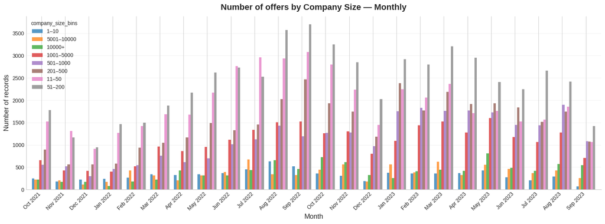

| company_size_bins | year | Month | 1–10 | % 1–10 | 5001–10000 | % 5001–10000 | 10000+ | % 10000+ | 1001–5000 | % 1001–5000 | 501–1000 | % 501–1000 | 201–500 | % 201–500 | 11–50 | % 11–50 | 51–200 | % 51–200 | Total |
| --- | --- | --- | --- | --- | --- | --- | --- | --- | --- | --- | --- | --- | --- | --- | --- | --- | --- | --- | --- |
| 0 | 2021 | Oct | 251 | 4.110000 | 224 | 3.670000 | 223 | 3.650000 | 658 | 10.770000 | 552 | 9.030000 | 897 | 14.680000 | 1528 | 25.000000 | 1778 | 29.100000 | 6111 |
| 1 | 2021 | Nov | 177 | 3.900000 | 205 | 4.510000 | 170 | 3.740000 | 424 | 9.340000 | 518 | 11.410000 | 567 | 12.490000 | 1314 | 28.940000 | 1166 | 25.680000 | 4541 |
| 2 | 2021 | Dec | 227 | 6.230000 | 109 | 2.990000 | 172 | 4.720000 | 415 | 11.390000 | 297 | 8.150000 | 565 | 15.500000 | 910 | 24.970000 | 949 | 26.040000 | 3644 |
| 3 | 2022 | Jan | 238 | 5.100000 | 170 | 3.640000 | 82 | 1.760000 | 403 | 8.640000 | 458 | 9.820000 | 584 | 12.520000 | 1268 | 27.190000 | 1461 | 31.330000 | 4664 |
| 4 | 2022 | Feb | 265 | 4.570000 | 424 | 7.310000 | 183 | 3.160000 | 522 | 9.000000 | 545 | 9.400000 | 938 | 16.180000 | 1425 | 24.580000 | 1496 | 25.800000 | 5798 |
| 5 | 2022 | Mar | 345 | 4.780000 | 319 | 4.420000 | 219 | 3.030000 | 964 | 13.340000 | 762 | 10.550000 | 1044 | 14.450000 | 1689 | 23.380000 | 1883 | 26.060000 | 7225 |
| 6 | 2022 | Apr | 326 | 4.380000 | 207 | 2.780000 | 428 | 5.750000 | 861 | 11.560000 | 614 | 8.250000 | 1163 | 15.620000 | 1675 | 22.500000 | 2172 | 29.170000 | 7446 |
| 7 | 2022 | May | 339 | 3.810000 | 313 | 3.520000 | 315 | 3.540000 | 954 | 10.720000 | 701 | 7.880000 | 1487 | 16.710000 | 2171 | 24.400000 | 2618 | 29.420000 | 8898 |
| 8 | 2022 | Jun | 368 | 3.670000 | 394 | 3.930000 | 314 | 3.130000 | 1114 | 11.120000 | 1012 | 10.100000 | 1325 | 13.220000 | 2764 | 27.580000 | 2729 | 27.240000 | 10020 |
| 9 | 2022 | Jul | 453 | 4.130000 | 676 | 6.160000 | 433 | 3.950000 | 1340 | 12.220000 | 1121 | 10.220000 | 1456 | 13.280000 | 2959 | 26.980000 | 2528 | 23.050000 | 10966 |
| 10 | 2022 | Aug | 629 | 4.800000 | 344 | 2.630000 | 653 | 4.990000 | 1505 | 11.490000 | 1430 | 10.920000 | 2023 | 15.450000 | 2937 | 22.430000 | 3575 | 27.300000 | 13096 |
| 11 | 2022 | Sep | 522 | 3.940000 | 321 | 2.420000 | 460 | 3.470000 | 1524 | 11.490000 | 1189 | 8.970000 | 2468 | 18.610000 | 3079 | 23.220000 | 3698 | 27.890000 | 13261 |
| 12 | 2022 | Oct | 363 | 3.010000 | 447 | 3.710000 | 721 | 5.990000 | 1264 | 10.500000 | 1265 | 10.500000 | 1929 | 16.020000 | 2801 | 23.260000 | 3253 | 27.010000 | 12043 |
| 13 | 2022 | Nov | 312 | 2.860000 | 565 | 5.180000 | 617 | 5.660000 | 1304 | 11.950000 | 1274 | 11.680000 | 1745 | 16.000000 | 2239 | 20.520000 | 2853 | 26.150000 | 10909 |
| 14 | 2022 | Dec | 189 | 2.650000 | 181 | 2.540000 | 323 | 4.540000 | 803 | 11.280000 | 973 | 13.660000 | 1182 | 16.600000 | 1446 | 20.310000 | 2024 | 28.420000 | 7121 |
| 15 | 2023 | Jan | 372 | 3.210000 | 567 | 4.890000 | 257 | 2.220000 | 1089 | 9.400000 | 1755 | 15.140000 | 2384 | 20.570000 | 2249 | 19.400000 | 2918 | 25.170000 | 11591 |
| 16 | 2023 | Feb | 360 | 3.260000 | 382 | 3.460000 | 408 | 3.690000 | 1437 | 13.000000 | 1831 | 16.570000 | 1770 | 16.020000 | 2062 | 18.660000 | 2802 | 25.350000 | 11052 |
| 17 | 2023 | Mar | 357 | 2.860000 | 622 | 4.990000 | 446 | 3.580000 | 1524 | 12.220000 | 1760 | 14.110000 | 2189 | 17.550000 | 2363 | 18.940000 | 3212 | 25.750000 | 12473 |
| 18 | 2023 | Apr | 371 | 3.450000 | 327 | 3.040000 | 419 | 3.900000 | 1281 | 11.920000 | 1771 | 16.480000 | 1918 | 17.850000 | 1708 | 15.890000 | 2952 | 27.470000 | 10747 |
| 19 | 2023 | May | 428 | 3.810000 | 551 | 4.910000 | 811 | 7.230000 | 1599 | 14.250000 | 1731 | 15.430000 | 1931 | 17.210000 | 1764 | 15.720000 | 2405 | 21.430000 | 11220 |
| 20 | 2023 | Jun | 271 | 2.870000 | 461 | 4.880000 | 490 | 5.180000 | 1174 | 12.420000 | 1449 | 15.330000 | 1838 | 19.450000 | 1526 | 16.140000 | 2243 | 23.730000 | 9452 |
| 21 | 2023 | Jul | 204 | 2.210000 | 370 | 4.000000 | 419 | 4.530000 | 1064 | 11.520000 | 1437 | 15.550000 | 1513 | 16.370000 | 1569 | 16.980000 | 2664 | 28.830000 | 9240 |
| 22 | 2023 | Aug | 287 | 2.740000 | 431 | 4.110000 | 569 | 5.430000 | 1274 | 12.160000 | 1900 | 18.130000 | 1743 | 16.630000 | 1858 | 17.730000 | 2418 | 23.070000 | 10480 |
| 23 | 2023 | Sep | 73 | 1.170000 | 257 | 4.130000 | 546 | 8.760000 | 707 | 11.350000 | 1086 | 17.430000 | 1071 | 17.190000 | 1069 | 17.160000 | 1421 | 22.810000 | 6230 |

#### Wnioski z analizy wielkości firm

✔ Firmy średnie (11–50, 51–200)

- Stabilne, największy udział w każdym roku
- Utrzymują pozycję bez większych spadków

✔ Duże firmy (501–1000, 1001–5000)

Wyraźny wzrost znaczenia w 2023

- Przejęły część udziału od firm najmniejszych i korporacji

✔ Giganci (10000+)

- Wzrost udziału w 2023, ale pozostają niszowi
- Ich aktywność jest falowa, reaguje na globalne wydarzenia (cięcia, hiring freeze)

✔ Mikrofirmy (1–10)

- Udział minimalny, praktycznie bez zmian
- Nie wpływają istotnie na rynek
7. Najważniejsze obserwacje biznesowe
- Rynek pracy IT w latach 2021–2023 był zdominowany przez średnie firmy, nie przez korporacje ani startupy.
- W 2023 zwiększyła się aktywność firm 500–5000 pracowników — sygnał stabilizacji i powrotu inwestycji.
- Największe firmy (10000+) zwiększały liczbę ofert, ale wciąż stanowiły niszową część rynku.
- Trendy wskazują na przesuwanie się rynku od startupów → ku większym, stabilnym organizacjom.

#### Podsumowanie wniosków:

W każdej obserwacji dominują firmy małe (11–50 i 51–200), razem zwykle 40–55% wszystkich rekordów.

Duże firmy (1001–5000, 5001–10000, 10000+) mają niski, ale dość stabilny udział — zwykle 10–20%.

Ogólny trend: im większa firma, tym bardziej stabilne, ale mniejsze wolumeny; główne wahania napędzają segmenty 11–50 i 51–200.

### 3.10.2 Zbadanie jakich rozmiarów firmy najczęściej oferują prace dla juniorów

Kategorie kolumny 'company_size_bins' tylko dla juniorów zawiera kategorie:

Number of unique values: **8**

- **51–200**: 4258 (26.09%)

- **11–50**: 4210 (25.8%)

- **201–500**: 2801 (17.17%)

- **501–1000**: 1597 (9.79%)

- **1001–5000**: 1321 (8.1%)

- **1–10**: 716 (4.39%)

- **10000+**: 707 (4.33%)

- **5001–10000**: 699 (4.28%)

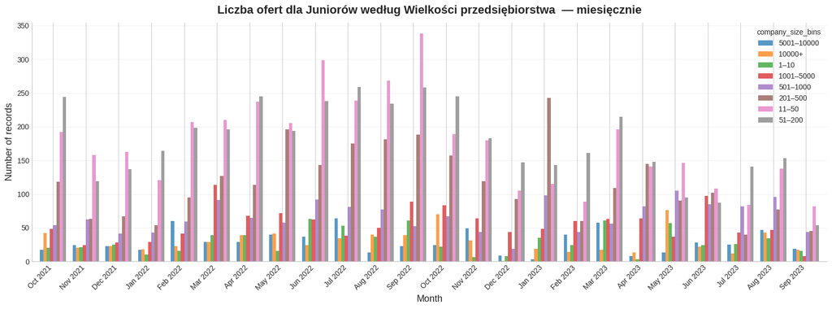

| company_size_bins | year | Month | 5001–10000 | % 5001–10000 | 10000+ | % 10000+ | 1–10 | % 1–10 | 1001–5000 | % 1001–5000 | 501–1000 | % 501–1000 | 201–500 | % 201–500 | 11–50 | % 11–50 | 51–200 | % 51–200 | Total |
| --- | --- | --- | --- | --- | --- | --- | --- | --- | --- | --- | --- | --- | --- | --- | --- | --- | --- | --- | --- |
| 0 | 2021 | Oct | 17 | 2.310000 | 42 | 5.710000 | 20 | 2.720000 | 48 | 6.530000 | 54 | 7.350000 | 118 | 16.050000 | 192 | 26.120000 | 244 | 33.200000 | 735 |
| 1 | 2021 | Nov | 24 | 4.890000 | 20 | 4.070000 | 21 | 4.280000 | 24 | 4.890000 | 62 | 12.630000 | 63 | 12.830000 | 158 | 32.180000 | 119 | 24.240000 | 491 |
| 2 | 2021 | Dec | 23 | 4.540000 | 23 | 4.540000 | 25 | 4.930000 | 28 | 5.520000 | 41 | 8.090000 | 67 | 13.210000 | 163 | 32.150000 | 137 | 27.020000 | 507 |
| 3 | 2022 | Jan | 17 | 3.730000 | 18 | 3.950000 | 10 | 2.190000 | 29 | 6.360000 | 43 | 9.430000 | 54 | 11.840000 | 121 | 26.540000 | 164 | 35.960000 | 456 |
| 4 | 2022 | Feb | 60 | 8.580000 | 23 | 3.290000 | 16 | 2.290000 | 41 | 5.870000 | 59 | 8.440000 | 95 | 13.590000 | 207 | 29.610000 | 198 | 28.330000 | 699 |
| 5 | 2022 | Mar | 29 | 3.470000 | 29 | 3.470000 | 39 | 4.670000 | 114 | 13.650000 | 91 | 10.900000 | 127 | 15.210000 | 210 | 25.150000 | 196 | 23.470000 | 835 |
| 6 | 2022 | Apr | 29 | 3.470000 | 39 | 4.670000 | 39 | 4.670000 | 68 | 8.130000 | 65 | 7.780000 | 114 | 13.640000 | 237 | 28.350000 | 245 | 29.310000 | 836 |
| 7 | 2022 | May | 40 | 4.870000 | 41 | 4.990000 | 16 | 1.950000 | 72 | 8.760000 | 58 | 7.060000 | 196 | 23.840000 | 205 | 24.940000 | 194 | 23.600000 | 822 |
| 8 | 2022 | Jun | 37 | 3.860000 | 24 | 2.510000 | 63 | 6.580000 | 62 | 6.470000 | 92 | 9.600000 | 143 | 14.930000 | 299 | 31.210000 | 238 | 24.840000 | 958 |
| 9 | 2022 | Jul | 64 | 6.790000 | 34 | 3.610000 | 53 | 5.620000 | 38 | 4.030000 | 81 | 8.590000 | 175 | 18.560000 | 239 | 25.340000 | 259 | 27.470000 | 943 |
| 10 | 2022 | Aug | 13 | 1.440000 | 40 | 4.440000 | 37 | 4.110000 | 50 | 5.560000 | 77 | 8.560000 | 181 | 20.110000 | 268 | 29.780000 | 234 | 26.000000 | 900 |
| 11 | 2022 | Sep | 23 | 2.190000 | 39 | 3.720000 | 61 | 5.820000 | 89 | 8.490000 | 52 | 4.960000 | 188 | 17.940000 | 338 | 32.250000 | 258 | 24.620000 | 1048 |
| 12 | 2022 | Oct | 24 | 2.800000 | 70 | 8.170000 | 22 | 2.570000 | 83 | 9.680000 | 67 | 7.820000 | 157 | 18.320000 | 189 | 22.050000 | 245 | 28.590000 | 857 |
| 13 | 2022 | Nov | 49 | 7.250000 | 31 | 4.590000 | 6 | 0.890000 | 64 | 9.470000 | 44 | 6.510000 | 119 | 17.600000 | 180 | 26.630000 | 183 | 27.070000 | 676 |
| 14 | 2022 | Dec | 9 | 2.110000 | 1 | 0.230000 | 8 | 1.880000 | 44 | 10.330000 | 19 | 4.460000 | 93 | 21.830000 | 105 | 24.650000 | 147 | 34.510000 | 426 |
| 15 | 2023 | Jan | 3 | 0.430000 | 19 | 2.700000 | 35 | 4.970000 | 48 | 6.820000 | 98 | 13.920000 | 243 | 34.520000 | 115 | 16.340000 | 143 | 20.310000 | 704 |
| 16 | 2023 | Feb | 40 | 8.130000 | 14 | 2.850000 | 24 | 4.880000 | 60 | 12.200000 | 44 | 8.940000 | 60 | 12.200000 | 89 | 18.090000 | 161 | 32.720000 | 492 |
| 17 | 2023 | Mar | 58 | 7.480000 | 17 | 2.190000 | 61 | 7.870000 | 63 | 8.130000 | 56 | 7.230000 | 109 | 14.060000 | 196 | 25.290000 | 215 | 27.740000 | 775 |
| 18 | 2023 | Apr | 8 | 1.320000 | 13 | 2.150000 | 3 | 0.500000 | 64 | 10.600000 | 82 | 13.580000 | 145 | 24.010000 | 141 | 23.340000 | 148 | 24.500000 | 604 |
| 19 | 2023 | May | 13 | 2.100000 | 76 | 12.280000 | 57 | 9.210000 | 37 | 5.980000 | 105 | 16.960000 | 90 | 14.540000 | 146 | 23.590000 | 95 | 15.350000 | 619 |
| 20 | 2023 | Jun | 28 | 5.060000 | 22 | 3.980000 | 24 | 4.340000 | 97 | 17.540000 | 85 | 15.370000 | 102 | 18.440000 | 108 | 19.530000 | 87 | 15.730000 | 553 |
| 21 | 2023 | Jul | 25 | 5.520000 | 12 | 2.650000 | 26 | 5.740000 | 43 | 9.490000 | 82 | 18.100000 | 40 | 8.830000 | 84 | 18.540000 | 141 | 31.130000 | 453 |
| 22 | 2023 | Aug | 47 | 7.400000 | 43 | 6.770000 | 34 | 5.350000 | 47 | 7.400000 | 96 | 15.120000 | 77 | 12.130000 | 138 | 21.730000 | 153 | 24.090000 | 635 |
| 23 | 2023 | Sep | 19 | 6.670000 | 17 | 5.960000 | 16 | 5.610000 | 8 | 2.810000 | 44 | 15.440000 | 45 | 15.790000 | 82 | 28.770000 | 54 | 18.950000 | 285 |

### Conclusions for Company Size

# 3.11 Financial Columns

For the purpose of analyzing salaries in the industry:

- A new DataFrame will be created containing only positions with salary ranges.
- Only salaries in PLN will be analyzed.
- Suspicious records will be removed.
- A "mean_salary" column will be created, containing the average value between "salary_from" and "salary_to".
- Everything will be analyzed for the three experience levels: "junior", "mid", and "senior".

```
Numer of records with salary: 150497
```

The 'salary_currency' column contains the following categories:

Number of unique values: **5**

- **pln**: 136672 (90.81%)

- **eur**: 7372 (4.9%)

- **usd**: 5675 (3.77%)

- **gbp**: 684 (0.45%)

- **chf**: 94 (0.06%)

```
There are 30 (0.02%) records with suspiciously low salaries that do not correspond to monthly wages.
```

#### Removal of suspicious records and offers with foreign currency.

#### Creation of the 'salary_mean' column

#### Examination of outlier values

We have **1254** outlier values, which is 0.92% of the entire dataset.  
They can be removed

1. Seniors
- Remote and partly-remote pay almost the same — medians are very close (around 22–25k).
- Office clearly pays more — medians ~26–28k with much higher upper ranges.
- Conclusion: Seniors in the office earn more than fully remote, contrary to expectations — but this is because office offers in the data generally represent the "highest paying" positions.
2. Mid-level
- Remote and partly-remote again almost identical: medians ~15–17k.
- Office again higher — medians ~18–20k.
- Conclusion: Same effect as above — office > the rest.
3. Juniors
- Remote ~7–9k (highest),
- Partly-remote ~7–8k,
- Office ~6–7k (lowest).

The only level where remote actually pays best.

#### Summary of trends

- Remote and partly-remote are practically identical → analyzing them separately is not necessary.
- Office paid more for mid/senior levels, showing that at that time there was no reversal of the trend favoring higher compensation for remote work.
- Juniors earn best in fully remote positions, which makes sense because remote juniors are typically sought in IT rather than by large corporations.

# Step 4. Correlation Matrix

## 4.1 Clasic Pearson's correlation

|  | company_size | salary_from | salary_to | lifetime_in_days | year | month | salary_mean |
| --- | --- | --- | --- | --- | --- | --- | --- |
| company_size | 1.000000 | 0.053266 | 0.062903 | -0.015490 | 0.072236 | -0.004427 | 0.059748 |
| salary_from | 0.053266 | 1.000000 | 0.915517 | -0.035822 | 0.170228 | -0.018362 | 0.974951 |
| salary_to | 0.062903 | 0.915517 | 1.000000 | -0.007262 | 0.155374 | -0.018966 | 0.982059 |
| lifetime_in_days | -0.015490 | -0.035822 | -0.007262 | 1.000000 | -0.143166 | 0.000058 | -0.020807 |
| year | 0.072236 | 0.170228 | 0.155374 | -0.143166 | 1.000000 | -0.520518 | 0.165703 |
| month | -0.004427 | -0.018362 | -0.018966 | 0.000058 | -0.520518 | 1.000000 | -0.019093 |
| salary_mean | 0.059748 | 0.974951 | 0.982059 | -0.020807 | 0.165703 | -0.019093 | 1.000000 |

### Conclusions:

The Pearson correlation matrix primarily shows linear dependencies between numerical variables, particularly strong relationships among "Salary From", "Salary To", and "Mean Salary". Correlations for categorical variables that were assigned numerical values should be interpreted with caution — Pearson only measures linear relationships between numbers and does not reflect the actual relationships between categories. Therefore, conclusions regarding categorical variables may not correspond to reality.

### 5.3 Using Categorical Variable Correlations with **Cramér's V**

#### Cramér’s V Matrix

Value range:

0 → no association

0–0.3 → weak association

0.3–0.5 → moderate association

0.5 → strong association

Values above 0.6–0.7 may cause Cramér’s V to appear inflated, suggesting a strong correlation even though in practice the association may not be that significant.

|  | city | country_code | marker_icon | workplace_type | company_size | experience_level | remote_interview | company_size_bins | type | open_to_hire_ukrainians |
| --- | --- | --- | --- | --- | --- | --- | --- | --- | --- | --- |
| city | 1.000000 | 0.989922 | 0.094094 | 0.351792 | 0.145524 | 0.114561 | 0.134550 | 0.125183 | 0.138395 | 0.161921 |
| country_code | 0.989922 | 1.000000 | 0.026829 | 0.038802 | 0.149950 | 0.032852 | 0.030520 | 0.033810 | 0.028081 | 0.031715 |
| marker_icon | 0.094094 | 0.026829 | 1.000000 | 0.148456 | 0.152352 | 0.164007 | 0.096938 | 0.108996 | 0.148442 | 0.060762 |
| workplace_type | 0.351792 | 0.038802 | 0.148456 | 1.000000 | 0.195731 | 0.138108 | 0.113494 | 0.068234 | 0.163566 | 0.031210 |
| company_size | 0.145524 | 0.149950 | 0.152352 | 0.195731 | 1.000000 | 0.184257 | 0.301601 | 1.000000 | 0.352118 | 0.162531 |
| experience_level | 0.114561 | 0.032852 | 0.164007 | 0.138108 | 0.184257 | 1.000000 | 0.018740 | 0.097564 | 0.171433 | 0.046232 |
| remote_interview | 0.134550 | 0.030520 | 0.096938 | 0.113494 | 0.301601 | 0.018740 | 1.000000 | 0.167066 | 0.106318 | 0.089780 |
| company_size_bins | 0.125183 | 0.033810 | 0.108996 | 0.068234 | 1.000000 | 0.097564 | 0.167066 | 1.000000 | 0.255629 | 0.056335 |
| type | 0.138395 | 0.028081 | 0.148442 | 0.163566 | 0.352118 | 0.171433 | 0.106318 | 0.255629 | 1.000000 | 0.006705 |
| open_to_hire_ukrainians | 0.161921 | 0.031715 | 0.060762 | 0.031210 | 0.162531 | 0.046232 | 0.089780 | 0.056335 | 0.006705 | 1.000000 |

#### Conclusions from the **Cramér's V** correlation analysis

1. Company size vs. employment type and recruitment
- The analysis showed that company size was associated with employment type (company_size – type ≈ 0.35).
- Larger companies offered various forms of employment (permanent contracts, B2B, mandates), while smaller companies more often used a single type of contract.

The relationship between company size and remote interviews (company_size – remote_interview ≈ 0.30) indicated that larger companies conducted interviews remotely more often, whereas smaller companies did so on-site more frequently.

2. Location vs. job type
- The analysis revealed a moderate association between city and workplace type (city – workplace_type ≈ 0.35).
- In larger cities, on-site or hybrid offers dominated, while in smaller cities, offers were more often remote.
3. Other variables were independent
- Experience level (experience_level) and openness to hiring Ukrainians (open_to_hire_ukrainians) did not show significant associations with other variables.
- This means that decisions regarding candidate experience level or hiring Ukrainians were not determined by location or company size.

#### Summary of the correlation analysis

The analysis showed that company size and location influenced job type and recruitment method.

Other characteristics of IT job offers in Poland from 2021–2023 were largely independent.

# 🧠⚙️ Krok 6 Wnioski i Odpowiedzi

## Answers to the Questions

### 1. What was the average lifespan of a job offer?

#### The average lifespan of an offer was **35.79** days.

### 2. Were there periodic increases and decreases in offers?

#### Yes — offers grew at the beginning of the year (January–Spring), stabilized in the summer, and dropped noticeably in the last quarter.

### 3. Which technologies were the most popular?

### 4. What was the situation for Python?

#### Two sources of information should be distinguished:

##### According to "Main technologies (icon)", the most popular technological directions were:

- JavaScript: 28,957 (13.26%)
- Java: 22,825 (10.45%)
- Testing: 15,221 (6.97%)
- .NET: 15,170 (6.95%)
- DevOps: 14,850 (6.8%)
- Data: 13,725 (6.29%)
- PM: 11,104 (5.09%)
- Python: 10,804 (4.95%)
- PHP: 9,808 (4.49%)

Python ranked 8th.

Excluding English as it is not a technology, Python ranked 4th.

### 5. How many offers were for juniors?

- Mid: 115,853 (53.06%)
- Senior: 86,158 (39.46%)
- Junior: 16,318 (7.47%)
- The job market clearly shifted toward more experienced specialists.
- In summary, the market increasingly preferred candidates with more experience. Junior participation declined noticeably, mid-level specialists remained important but slightly shrinking, while seniors gradually assumed a dominant position.

### 6. How did the number of junior offers compare to company size?

Proportion of junior offers by company size:

- 51–200: 4,258 (26.09%)
- 11–50: 4,210 (25.8%)
- 201–500: 2,801 (17.17%)
- 501–1000: 1,597 (9.79%)
- 1001–5000: 1,321 (8.1%)
- 1–10: 716 (4.39%)
- 10,000+: 707 (4.33%)
- 5001–10000: 699 (4.28%)

### 7. What was the general salary overview?

- **Seniors**: Office positions paid more (~26–28k) than fully remote or partly-remote (~22–25k), because office listings generally represented higher-paying roles.
- **Mid-level**: Mid-level employees in office offers received higher salaries (~18–20k) than in remote and partly-remote (~15–17k), repeating the effect observed for seniors.
- **Juniors**: Juniors in remote offers earned the most (~7–9k), exceeding partly-remote (~7–8k) and office (~6–7k), showing that remote offers for beginners were more competitive.

### Correlation Analysis

Classical Pearson correlation analysis did not show notable correlations among categorical columns.

The best-known method in such a case is the **Cramér’s V correlation matrix**.

Larger companies were more often corporations, smaller ones startups.

- Remote interview possibility (remote_interview) → V = 0.3016  
  Larger companies offered remote interviews more frequently.
- Job type (workplace_type) moderately depends on city (city) → V = 0.3518  
  Some cities had more office positions, others more remote or hybrid.

```
OK
```